# Similarity Judgment Task Analysis: Adjs Phys-Soc

morgan moyer

2025-07-09

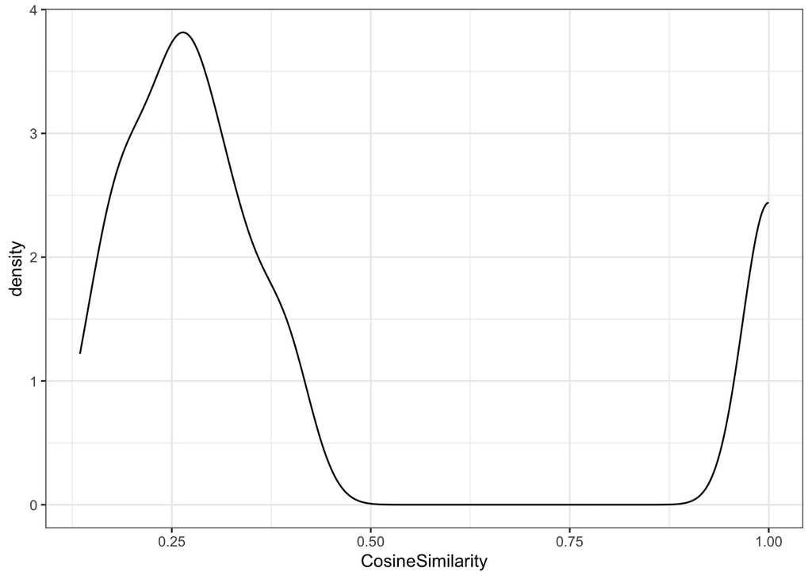

```r
ggplot(d, aes(CosineSimilarity)) +
  geom_density(alpha = .5)
```

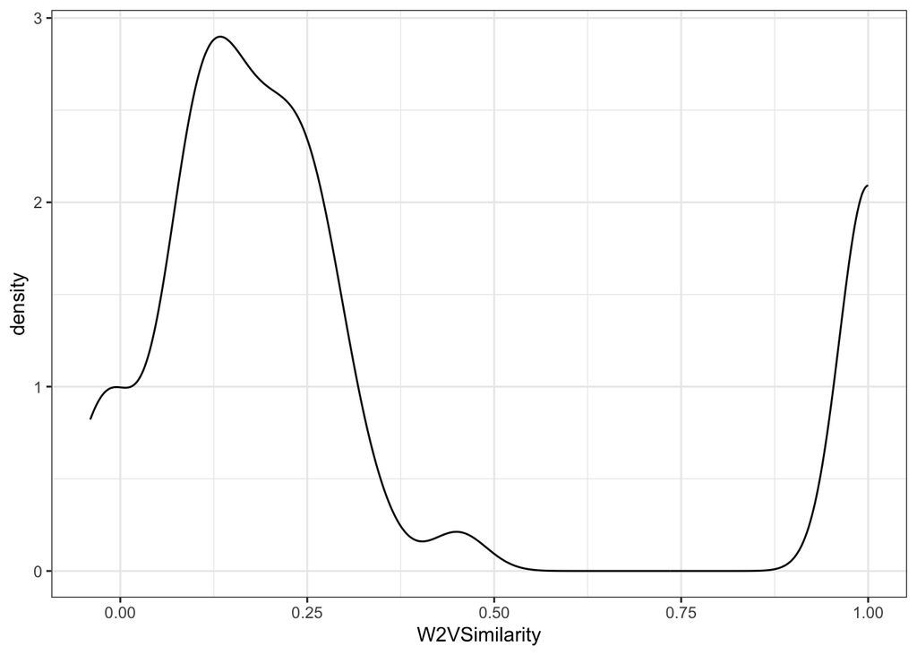

```r
ggplot(d, aes(W2VSimilarity)) +
  geom_density(alpha = .5)
```

```r
names(d)
```

```
## [1] "WordPair"         "X"                "ID.Ibex"          "Response"
## [5] "FeatureMatch"     "Word1"            "Word2"            "W2VSimilarity"
## [9] "CosineSimilarity"
```

```r
dcen <- d %>%
  mutate(WordPair = as.factor(WordPair),
         ID.Ibex = as.factor(ID.Ibex),
         FeatureMatch = as.factor(FeatureMatch),
         cResponse = as.numeric(Response)-mean(as.numeric(Response)))

m <- lmer(cResponse ~ FeatureMatch + (1|WordPair) + (1+FeatureMatch|ID.Ibex), data = dcen)
```

```
## boundary (singular) fit: see help('isSingular')
```

```r
summary(m)
```

```
## Linear mixed model fit by REML. t-tests use Satterthwaite's method [
## lmerModLmerTest]
## Formula: cResponse ~ FeatureMatch + (1 | WordPair) + (1 + FeatureMatch |
##     ID.Ibex)
##    Data: dcen
##
## REML criterion at convergence: 4285.8
##
## Scaled residuals:
##     Min      1Q  Median      3Q     Max
## -2.9774 -0.4583 -0.0246  0.2485  3.5980
##
## Random effects:
##  Groups   Name                            Variance Std.Dev. Corr
##  WordPair (Intercept)                      44.860   6.698
##  ID.Ibex  (Intercept)                      29.237   5.407
##           FeatureMatchMaxMatch            211.114  14.530    0.52
##           FeatureMatchMaxMismatch           3.415   1.848    0.54  0.80
##           FeatureMatchSelfPair             37.334   6.110   -0.97 -0.36 -0.55
##           FeatureMatchValenceMatchingOnly 191.733  13.847    0.51  0.83  0.36
##  Residual                                 270.093  16.435
##
##
##
##
##
##
##  -0.28
##
## Number of obs: 500, groups:  WordPair, 50; ID.Ibex, 10
##
## Fixed effects:
##                                 Estimate Std. Error      df t value Pr(>|t|)
## (Intercept)                      -27.456      3.180  25.277  -8.635 5.19e-09
## FeatureMatchMaxMatch              23.000      5.957  15.407   3.861  0.00147
## FeatureMatchMaxMismatch            1.500      3.836  43.062   0.391  0.69771
## FeatureMatchSelfPair              90.410      4.255  28.213  21.247  < 2e-16
## FeatureMatchValenceMatchingOnly   22.370      5.792  16.117   3.862  0.00136
##
## (Intercept)                     ***
## FeatureMatchMaxMatch            **
## FeatureMatchMaxMismatch
## FeatureMatchSelfPair            ***
## FeatureMatchValenceMatchingOnly **
## ---
## Signif. codes:  0 '***' 0.001 '**' 0.01 '*' 0.05 '.' 0.1 ' ' 1
##
## Correlation of Fixed Effects:
##             (Intr) FtrMtchMxMt FtrMtchMxMs FtrMSP
## FtrMtchMxMt -0.165
## FtrMtchMxMs -0.545  0.408
## FtrMtchSlfP -0.767  0.156       0.403
## FtrMtchVlMO -0.182  0.694       0.365       0.195
## optimizer (nloptwrap) convergence code: 0 (OK)
## boundary (singular) fit: see help('isSingular')
```

### Plot fixed effect estimates with confidence intervals

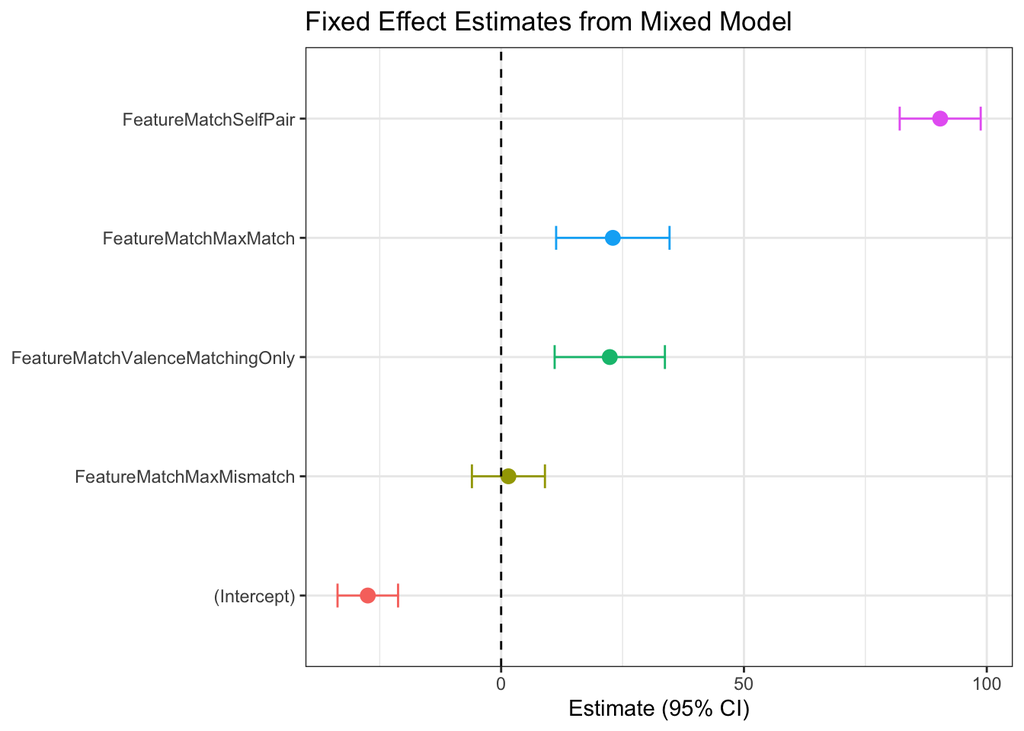

```r
# Tidy the model output
coefs <- tidy(m, effects = "fixed")
# Reorder by effect size for prettier plotting
coefs$term <- factor(coefs$term, levels = coefs$term[order(coefs$estimate)])

# Then replot
ggplot(coefs, aes(x = estimate, y = term, color = term)) +
  geom_point(size = 3) +
  geom_errorbarh(aes(xmin = estimate - 1.96 * std.error,
                     xmax = estimate + 1.96 * std.error), height = 0.2) +
  geom_vline(xintercept = 0, linetype = "dashed") +
  # theme_minimal(base_size = 14) +
  labs(title = "Fixed Effect Estimates from Mixed Model",
       x = "Estimate (95% CI)", y = NULL) +
  theme(legend.position="none")
```

### Plot predicted values vs. predictors

You can create a dataset of predicted values from your model and plot how the response changes with predictors:

```r
newdata <- expand.grid(
  FeatureMatch = levels(dcen$FeatureMatch))
```

2. Get predicted values and standard errors from the model

```r
pred <- predict(m, newdata = newdata, re.form = NA, se.fit = TRUE)
```

3. Add predictions and confidence intervals to newdata

```r
newdata$fit <- pred$fit
newdata$se <- pred$se.fit
newdata <- newdata %>%
  mutate(
    conf.low = fit - 1.96 * se,
    conf.high = fit + 1.96 * se
  )
```

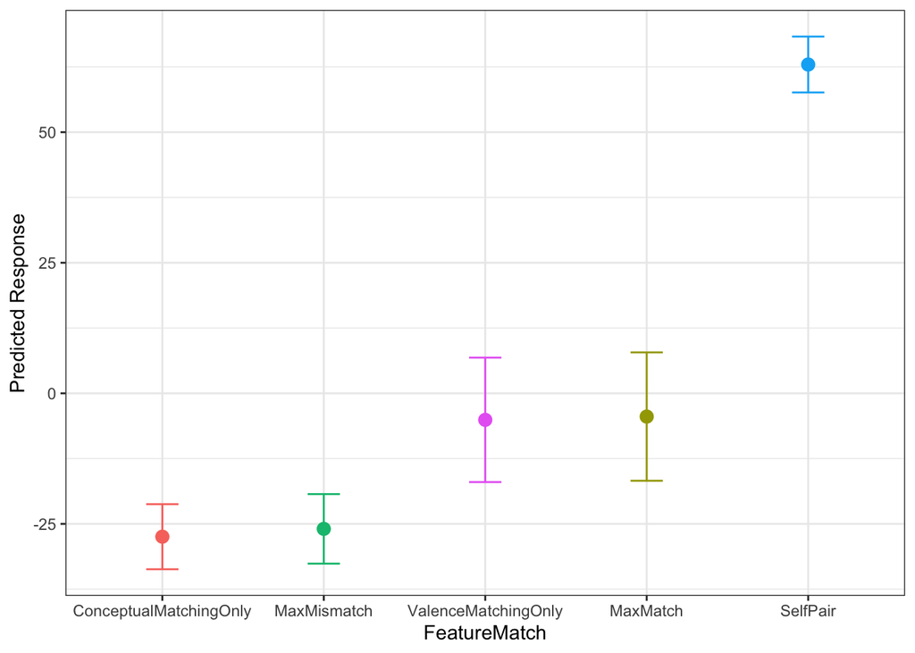

```r
ggplot(newdata, aes(x = reorder(FeatureMatch,fit), y = fit, color = FeatureMatch, fill = FeatureMatch)) +
  geom_point(size = 3) +
  geom_errorbar(aes(ymin = conf.low, ymax = conf.high), width = 0.2) +
  # theme_minimal() +
  labs(x = "FeatureMatch", y = "Predicted Response", color = "FeatureMatch", fill = "FeatureMatch") +
  theme(legend.position="none")
```

## You can visualize individual random effect estimates:

What you get from the plot: A visual summary of the variability in random effects across levels of your grouping factors.

Helps you identify:

Which groups (subjects/items) deviate strongly from the average effect,

How precise these deviations are,

Whether there are outliers or patterns in random effects.

Example interpretation: If a subject’s random intercept dot is far from zero with narrow error bars, that subject consistently differs from the average intercept with high certainty.

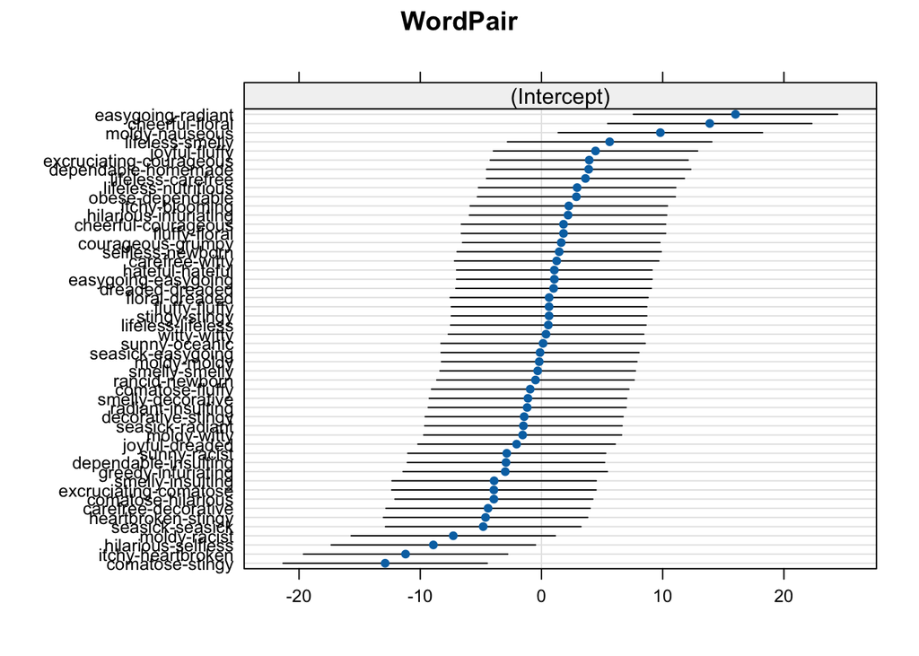

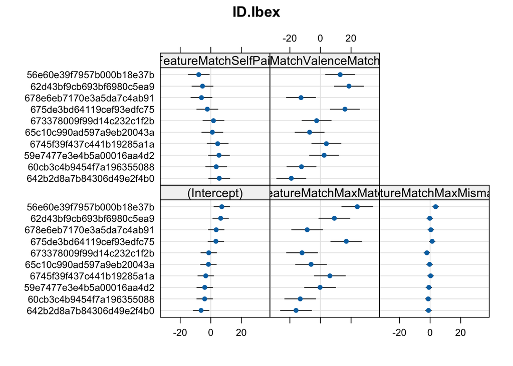

```r
dotplot(ranef(m, condVar=TRUE))
```

## Check model diagnostics

For residuals, fitted vs residuals, etc.:

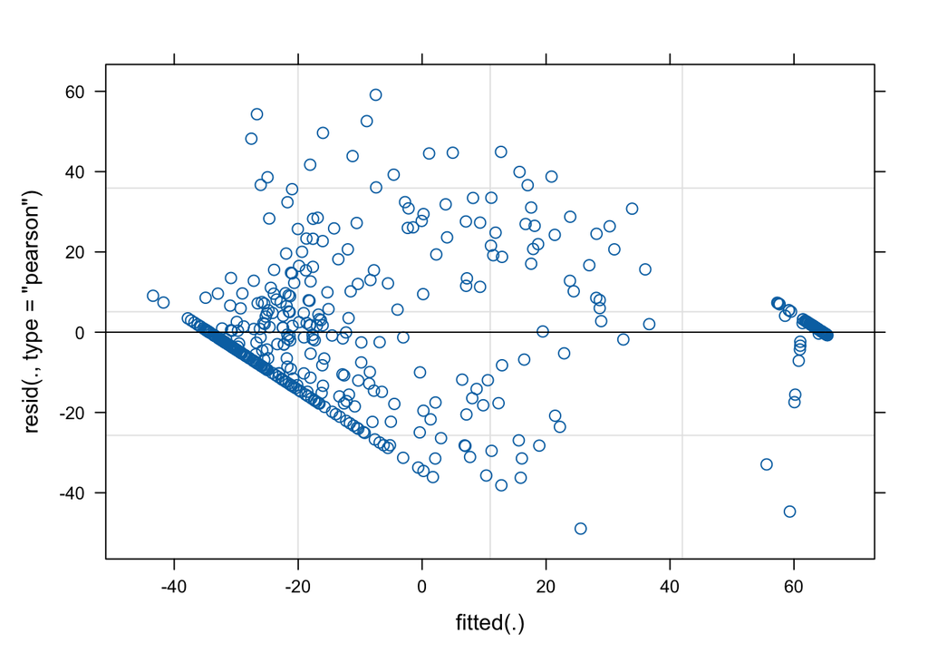

```r
plot(m)
```

# Does Similarity predict or interact with FeatureMatch?

## Cosine Similarity from Transformer Models

- No.

```r
m.full <- lmer(cResponse ~ FeatureMatch*CosineSimilarity + (1|WordPair) + (1|ID.Ibex), data = dcen)
```

```
## fixed-effect model matrix is rank deficient so dropping 1 column / coefficient
```

```r
summary(m.full)
```

```
## Linear mixed model fit by REML. t-tests use Satterthwaite's method [
## lmerModLmerTest]
## Formula: cResponse ~ FeatureMatch * CosineSimilarity + (1 | WordPair) +
##     (1 | ID.Ibex)
##    Data: dcen
##
## REML criterion at convergence: 4317.1
##
## Scaled residuals:
##     Min      1Q  Median      3Q     Max
## -2.3049 -0.6342 -0.1196  0.3844  3.2289
##
## Random effects:
##  Groups   Name        Variance Std.Dev.
##  WordPair (Intercept)  35.81    5.984
##  ID.Ibex  (Intercept)  76.62    8.753
##  Residual             332.36   18.231
## Number of obs: 500, groups:  WordPair, 50; ID.Ibex, 10
##
## Fixed effects:
##                                                  Estimate Std. Error      df
## (Intercept)                                       -26.408      9.579  46.724
## FeatureMatchMaxMatch                               -1.323     15.677  41.000
## FeatureMatchMaxMismatch                            -7.157     13.491  41.000
## FeatureMatchSelfPair                               93.326     24.713  41.000
## FeatureMatchValenceMatchingOnly                     8.403     13.785  41.000
## CosineSimilarity                                   -3.964     33.218  41.000
## FeatureMatchMaxMatch:CosineSimilarity              85.568     54.826  41.000
## FeatureMatchMaxMismatch:CosineSimilarity           36.177     52.296  41.000
## FeatureMatchValenceMatchingOnly:CosineSimilarity   49.871     48.516  41.000
##                                                  t value Pr(>|t|)
## (Intercept)                                       -2.757 0.008302 **
## FeatureMatchMaxMatch                              -0.084 0.933162
## FeatureMatchMaxMismatch                           -0.530 0.598642
## FeatureMatchSelfPair                               3.776 0.000506 ***
## FeatureMatchValenceMatchingOnly                    0.610 0.545490
## CosineSimilarity                                  -0.119 0.905594
## FeatureMatchMaxMatch:CosineSimilarity              1.561 0.126278
## FeatureMatchMaxMismatch:CosineSimilarity           0.692 0.492980
## FeatureMatchValenceMatchingOnly:CosineSimilarity   1.028 0.310011
```

[output cut: 9 more lines]

```
## CosinSmlrty    -0.917  0.560       0.651      -0.989  0.637
## FtrMtchMxMt:CS  0.556 -0.971      -0.395       0.599 -0.386 -0.606
## FtrMtchMxMs:CS  0.583 -0.356      -0.960       0.628 -0.405 -0.635
## FtrMtVMO:CS     0.628 -0.384      -0.446       0.677 -0.963 -0.685
##                FtrMtchMxMt:CS FtrMtchMxMs:CS
## FtrMtchMxMt
## FtrMtchMxMs
## FtrMtchSlfP
## FtrMtchVlMO
## CosinSmlrty
## FtrMtchMxMt:CS
## FtrMtchMxMs:CS  0.385
## FtrMtVMO:CS     0.415          0.435
## fit warnings:
## fixed-effect model matrix is rank deficient so dropping 1 column / coefficient
```

## Does adding Cosine Similarity explain any more variance in the data?

- no

```r
m.s <- lmer(cResponse ~ FeatureMatch + (1|WordPair) + (1|ID.Ibex), data = dcen)

anova(m.s, m.full, REML=FALSE)
```

```
## refitting model(s) with ML (instead of REML)
```

```
## Data: dcen
## Models:
## m.s: cResponse ~ FeatureMatch + (1 | WordPair) + (1 | ID.Ibex)
## m.full: cResponse ~ FeatureMatch * CosineSimilarity + (1 | WordPair) + (1 | ID.Ibex)
##        npar    AIC    BIC  logLik deviance  Chisq Df Pr(>Chisq)
## m.s       8 4396.0 4429.7 -2190.0   4380.0
## m.full   12 4397.4 4448.0 -2186.7   4373.4 6.5411  4     0.1622
```

### Plot fixed effect estimates with confidence intervals

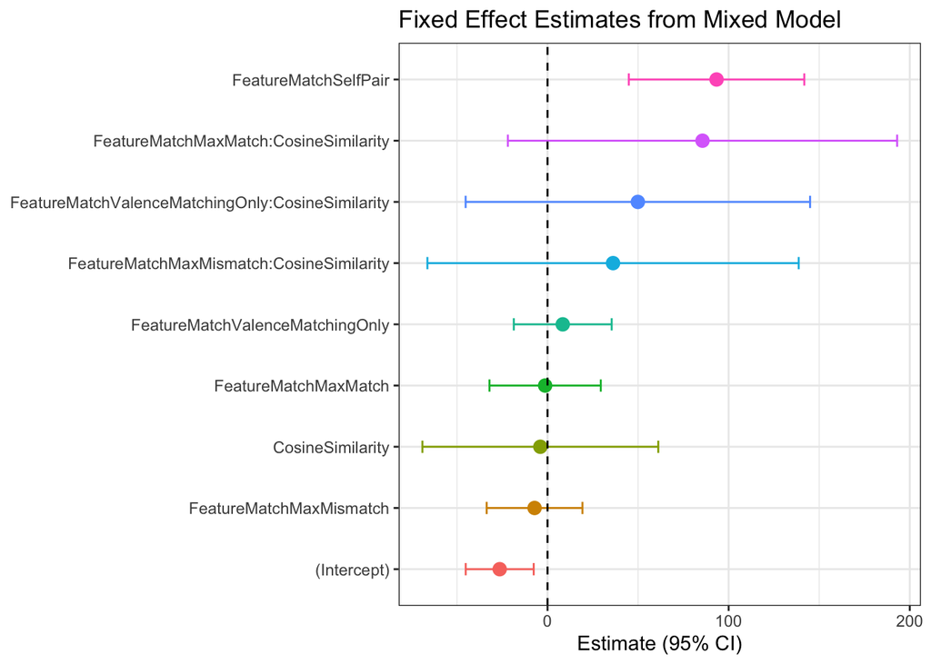

```r
# Tidy the model output
coefs <- tidy(m.full, effects = "fixed")

# Reorder by effect size for prettier plotting
coefs$term <- factor(coefs$term, levels = coefs$term[order(coefs$estimate)])

# Then replot
ggplot(coefs, aes(x = estimate, y = term, color = term)) +
  geom_point(size = 3) +
  geom_errorbarh(aes(xmin = estimate - 1.96 * std.error,
                     xmax = estimate + 1.96 * std.error), height = 0.2) +
  geom_vline(xintercept = 0, linetype = "dashed") +
  # theme_minimal(base_size = 14) +
  labs(title = "Fixed Effect Estimates from Mixed Model",
       x = "Estimate (95% CI)", y = NULL) +
  theme(legend.position="none")
```

## Word-2-Vec Similarity

```r
m.full <- lmer(cResponse ~ FeatureMatch*W2VSimilarity + (1|WordPair) + (1|ID.Ibex), data = dcen)
```

```
## fixed-effect model matrix is rank deficient so dropping 1 column / coefficient
```

```r
summary(m.full)
```

```
## Linear mixed model fit by REML. t-tests use Satterthwaite's method [
## lmerModLmerTest]
## Formula: cResponse ~ FeatureMatch * W2VSimilarity + (1 | WordPair) + (1 |
##     ID.Ibex)
##    Data: dcen
##
## REML criterion at convergence: 4310.4
##
## Scaled residuals:
##     Min      1Q  Median      3Q     Max
## -2.3473 -0.5961 -0.1187  0.3448  3.5093
##
## Random effects:
##  Groups   Name        Variance Std.Dev.
##  WordPair (Intercept)  23.88    4.887
##  ID.Ibex  (Intercept)  76.62    8.753
##  Residual             332.36   18.231
## Number of obs: 500, groups:  WordPair, 50; ID.Ibex, 10
##
## Fixed effects:
##                                               Estimate Std. Error      df
## (Intercept)                                    -29.267      4.462  34.893
## FeatureMatchMaxMatch                             1.940     11.108  41.000
## FeatureMatchMaxMismatch                          2.551      5.031  41.000
## FeatureMatchSelfPair                            79.015     16.439  41.000
## FeatureMatchValenceMatchingOnly                  3.744      7.709  41.000
## W2VSimilarity                                   13.206     18.645  41.000
## FeatureMatchMaxMatch:W2VSimilarity              77.629     44.839  41.000
## FeatureMatchMaxMismatch:W2VSimilarity           -5.495     33.237  41.000
## FeatureMatchValenceMatchingOnly:W2VSimilarity  109.789     43.007  41.000
##                                               t value Pr(>|t|)
## (Intercept)                                    -6.559 1.45e-07 ***
## FeatureMatchMaxMatch                            0.175   0.8622
## FeatureMatchMaxMismatch                         0.507   0.6148
## FeatureMatchSelfPair                            4.806 2.09e-05 ***
## FeatureMatchValenceMatchingOnly                 0.486   0.6298
## W2VSimilarity                                   0.708   0.4828
## FeatureMatchMaxMatch:W2VSimilarity              1.731   0.0909 .
## FeatureMatchMaxMismatch:W2VSimilarity          -0.165   0.8695
## FeatureMatchValenceMatchingOnly:W2VSimilarity   2.553   0.0145 *
```

[output cut: 9 more lines]

```
## W2VSimilrty      -0.573  0.230       0.508      -0.979  0.332
## FtrMtchMxMt:W2VS  0.238 -0.936      -0.211       0.407 -0.138 -0.416
## FtrMtchMxMs:W2VS  0.321 -0.129      -0.731       0.549 -0.186 -0.561
## FtMVMO:W2VS       0.248 -0.100      -0.220       0.424 -0.897 -0.434
##                  FtrMtchMxMt:W2VS FtrMtchMxMs:W2VS
## FtrMtchMxMt
## FtrMtchMxMs
## FtrMtchSlfP
## FtrMtchVlMO
## W2VSimilrty
## FtrMtchMxMt:W2VS
## FtrMtchMxMs:W2VS  0.233
## FtMVMO:W2VS       0.180            0.243
## fit warnings:
## fixed-effect model matrix is rank deficient so dropping 1 column / coefficient
```

```r
m.s <- lmer(cResponse ~ FeatureMatch + (1|WordPair) + (1|ID.Ibex), data = dcen)
```

## Does adding Word-2-Vec Similarity explain any more variance in the data?

- Yes

```r
anova(m.s, m.full, REML=FALSE)
```

```
## refitting model(s) with ML (instead of REML)
```

```
## Data: dcen
## Models:
## m.s: cResponse ~ FeatureMatch + (1 | WordPair) + (1 | ID.Ibex)
## m.full: cResponse ~ FeatureMatch * W2VSimilarity + (1 | WordPair) + (1 | ID.Ibex)
##        npar    AIC    BIC  logLik deviance  Chisq Df Pr(>Chisq)
## m.s       8 4396.0 4429.7 -2190.0   4380.0
## m.full   12 4388.1 4438.7 -2182.1   4364.1 15.857  4   0.003217 **
## ---
## Signif. codes:  0 '***' 0.001 '**' 0.01 '*' 0.05 '.' 0.1 ' ' 1
```

### Plot fixed effect estimates with confidence intervals

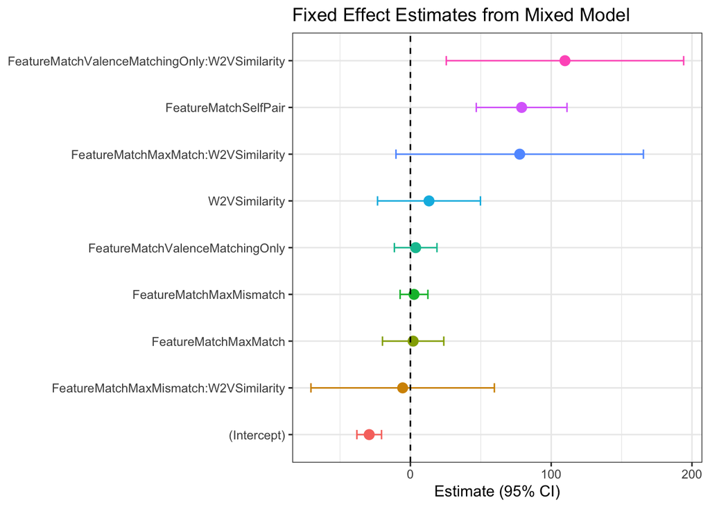

```r
# Tidy the model output
coefs <- tidy(m.full, effects = "fixed")

# Reorder by effect size for prettier plotting
coefs$term <- factor(coefs$term, levels = coefs$term[order(coefs$estimate)])

# Then replot
ggplot(coefs, aes(x = estimate, y = term, color = term)) +
  geom_point(size = 3) +
  geom_errorbarh(aes(xmin = estimate - 1.96 * std.error,
                     xmax = estimate + 1.96 * std.error), height = 0.2) +
  geom_vline(xintercept = 0, linetype = "dashed") +
  # theme_minimal(base_size = 14) +
  labs(title = "Fixed Effect Estimates from Mixed Model",
       x = "Estimate (95% CI)", y = NULL) +
  theme(legend.position="none")
```

### Plot predicted values vs. predictors

You can create a dataset of predicted values from your model and plot how the response changes with predictors:

1. Create a new dataset with combinations of predictors
- Generates all combinations of levels of FeatureMatch (a factor) and a sequence of W2VSimilarity values from -0.01 to 1 (100 points).
- Because: You want to predict your response across a continuous range of W2VSimilarity for each FeatureMatch group.

```r
newdata <- expand.grid(
  FeatureMatch = levels(dcen$FeatureMatch),
  W2VSimilarity = seq(-0.01, 1, length.out = 100)
)
```

2. Get predicted values and standard errors from the model

```r
pred <- predict(m.full, newdata = newdata, re.form = NA, se.fit = TRUE)
```

3. Add predictions and confidence intervals to newdata

```r
newdata$fit <- pred$fit
newdata$se <- pred$se.fit
newdata <- newdata %>%
  mutate(
    conf.low = fit - 1.96 * se,
    conf.high = fit + 1.96 * se
  )
```

4. Plot predicted lines with ribbons for confidence intervals

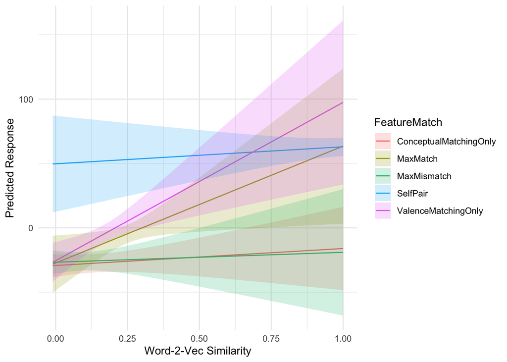

```r
ggplot(newdata, aes(x = W2VSimilarity, y = fit, color = FeatureMatch, fill = FeatureMatch)) +
  geom_line() +
  geom_ribbon(aes(ymin = conf.low, ymax = conf.high), alpha = 0.2, color = NA) +
  theme_minimal() +
  labs(x = "Word-2-Vec Similarity", y = "Predicted Response", color = "FeatureMatch", fill = "FeatureMatch")
```

### Visualize individual random effect estimates:

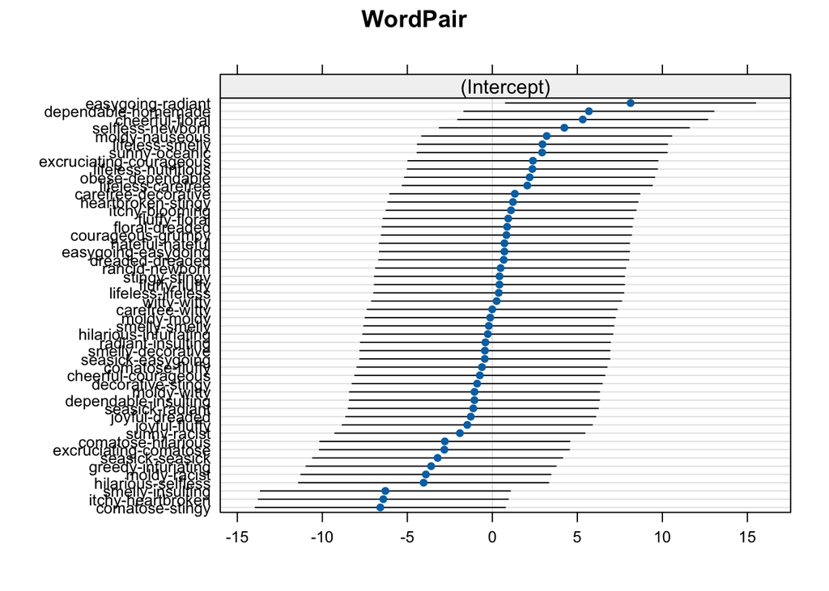

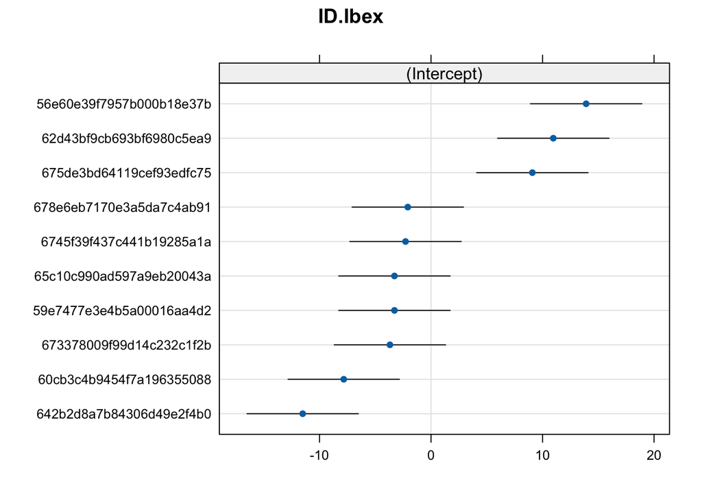

```r
dotplot(ranef(m.full, condVar=TRUE))
```

### Check model diagnostics

For residuals, fitted vs residuals, etc.:

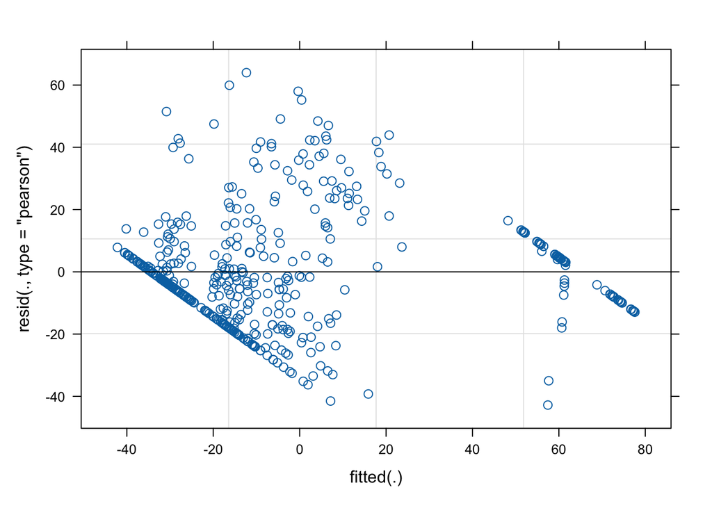

```r
plot(m.full)
```

# Similarity Alone

```r
m <- lmer(cResponse ~ W2VSimilarity + (1|WordPair) + (1|ID.Ibex), data = dcen)
summary(m)
```

```
## Linear mixed model fit by REML. t-tests use Satterthwaite's method [
## lmerModLmerTest]
## Formula: cResponse ~ W2VSimilarity + (1 | WordPair) + (1 | ID.Ibex)
##    Data: dcen
##
## REML criterion at convergence: 4402.9
##
## Scaled residuals:
##     Min      1Q  Median      3Q     Max
## -2.4571 -0.5604 -0.1530  0.3389  3.4821
##
## Random effects:
##  Groups   Name        Variance Std.Dev.
##  WordPair (Intercept)  95.61    9.778
##  ID.Ibex  (Intercept)  76.62    8.753
##  Residual             332.36   18.231
## Number of obs: 500, groups:  WordPair, 50; ID.Ibex, 10
##
## Fixed effects:
##               Estimate Std. Error      df t value Pr(>|t|)
## (Intercept)    -30.518      3.546  19.261  -8.607    5e-08 ***
## W2VSimilarity   92.274      4.619  48.000  19.976   <2e-16 ***
## ---
## Signif. codes:  0 '***' 0.001 '**' 0.01 '*' 0.05 '.' 0.1 ' ' 1
##
## Correlation of Fixed Effects:
##             (Intr)
## W2VSimilrty -0.431
```

```r
m <- lmer(cResponse ~ CosineSimilarity + (1|WordPair) + (1|ID.Ibex), data = dcen)
summary(m)
```

```
## Linear mixed model fit by REML. t-tests use Satterthwaite's method [
## lmerModLmerTest]
## Formula: cResponse ~ CosineSimilarity + (1 | WordPair) + (1 | ID.Ibex)
##    Data: dcen
##
## REML criterion at convergence: 4412.1
##
## Scaled residuals:
##     Min      1Q  Median      3Q     Max
## -2.3635 -0.5515 -0.1455  0.3320  3.4414
##
## Random effects:
##  Groups   Name        Variance Std.Dev.
##  WordPair (Intercept) 123.99   11.135
##  ID.Ibex  (Intercept)  76.63    8.754
##  Residual             332.36   18.231
## Number of obs: 500, groups:  WordPair, 50; ID.Ibex, 10
##
## Fixed effects:
##                  Estimate Std. Error      df t value Pr(>|t|)
## (Intercept)       -43.549      4.094  29.794  -10.64 1.16e-11 ***
## CosineSimilarity  105.327      5.903  48.001   17.84  < 2e-16 ***
## ---
## Signif. codes:  0 '***' 0.001 '**' 0.01 '*' 0.05 '.' 0.1 ' ' 1
##
## Correlation of Fixed Effects:
##             (Intr)
## CosinSmlrty -0.596
```